# b0ecfa39-aa26-4bcf-9c56-9ecbfef2d80d

```python
import pandas as pd
import numpy as np
from matplotlib import pyplot as plt
import scipy.stats as stats
%matplotlib inline
```

```python
def proverka(chech_data):
    dict_1 = {}
    for item in chech_data.columns:
        dict_1[item] = chech_data[item].isnull().sum()
    dict_1 = dict(sorted(dict_1.items(), key=lambda x: x[1], reverse=True))
    nancute = []
    for key,item in dict_1.items():
        print('''В столбце {} имеется {} пропущенных значений'''.format(key, item))


def proverka_zero(chech_data):
    dict_1 = {}
    for item in chech_data.columns:
        dict_1[item] = chech_data[item].isin([0]).sum()
    dict_1 = dict(sorted(dict_1.items(), key=lambda x: x[1], reverse=True))
    nancute = []
    for key,item in dict_1.items():
        print('''В столбце {} имеется кол-во значений, которые равны 0 : {} '''.format(key, item))

def proverka_minus(chech_data):
    dict_1 = {}
    for item in chech_data.columns:
        try:
            dict_1[item] = len(chech_data[chech_data[item] < 0])
        except:
            pass
    dict_1 = dict(sorted(dict_1.items(), key=lambda x: x[1], reverse=True))
    nancute = []
    for key,item in dict_1.items():
        print('''В столбце {} имеется {} отрицательные значений'''.format(key, item))
```

```python
hypothesis = pd.read_csv('/datasets/hypothesis.csv')
```

```python
hypothesis
```

|  | Hypothesis | Reach | Impact | Confidence | Efforts |
| --- | --- | --- | --- | --- | --- |
| 0 | Добавить два новых канала привлечения трафика,... | 3 | 10 | 8 | 6 |
| 1 | Запустить собственную службу доставки, что сок... | 2 | 5 | 4 | 10 |
| 2 | Добавить блоки рекомендаций товаров на сайт ин... | 8 | 3 | 7 | 3 |
| 3 | Изменить структура категорий, что увеличит кон... | 8 | 3 | 3 | 8 |
| 4 | Изменить цвет фона главной страницы, чтобы уве... | 3 | 1 | 1 | 1 |
| 5 | Добавить страницу отзывов клиентов о магазине,... | 3 | 2 | 2 | 3 |
| 6 | Показать на главной странице баннеры с актуаль... | 5 | 3 | 8 | 3 |
| 7 | Добавить форму подписки на все основные страни... | 10 | 7 | 8 | 5 |
| 8 | Запустить акцию, дающую скидку на товар в день... | 1 | 9 | 9 | 5 |

```python
proverka(hypothesis)
print('-----------')
proverka_zero(hypothesis)
print('------------')
proverka_minus(hypothesis)
```

```
В столбце Hypothesis имеется 0 пропущенных значений
В столбце Reach имеется 0 пропущенных значений
В столбце Impact имеется 0 пропущенных значений
В столбце Confidence имеется 0 пропущенных значений
В столбце Efforts имеется 0 пропущенных значений
-----------
В столбце Hypothesis имеется кол-во значений, которые равны 0 : 0
В столбце Reach имеется кол-во значений, которые равны 0 : 0
В столбце Impact имеется кол-во значений, которые равны 0 : 0
В столбце Confidence имеется кол-во значений, которые равны 0 : 0
В столбце Efforts имеется кол-во значений, которые равны 0 : 0
------------
В столбце Reach имеется 0 отрицательные значений
В столбце Impact имеется 0 отрицательные значений
В столбце Confidence имеется 0 отрицательные значений
В столбце Efforts имеется 0 отрицательные значений
```

```python
hypothesis.info()
```

```
<class 'pandas.core.frame.DataFrame'>
RangeIndex: 9 entries, 0 to 8
Data columns (total 5 columns):
Hypothesis    9 non-null object
Reach         9 non-null int64
Impact        9 non-null int64
Confidence    9 non-null int64
Efforts       9 non-null int64
dtypes: int64(4), object(1)
memory usage: 488.0+ bytes
```

### Часть 1

```python
hypothesis['ICE'] = (hypothesis['Impact'] * hypothesis['Confidence']) / hypothesis['Efforts']
```

```python
hypothesis['RICE'] = (hypothesis['Impact'] * hypothesis['Confidence'] * hypothesis['Reach']) / hypothesis['Efforts']
```

```python
ice_top = hypothesis[['Hypothesis', 'Reach', 'Impact', 'Confidence', 'Efforts', 'ICE']].sort_values(by = 'ICE', ascending = False).reset_index(drop=True)
ice_top
```

|  | Hypothesis | Reach | Impact | Confidence | Efforts | ICE |
| --- | --- | --- | --- | --- | --- | --- |
| 0 | Запустить акцию, дающую скидку на товар в день... | 1 | 9 | 9 | 5 | 16.200000 |
| 1 | Добавить два новых канала привлечения трафика,... | 3 | 10 | 8 | 6 | 13.333333 |
| 2 | Добавить форму подписки на все основные страни... | 10 | 7 | 8 | 5 | 11.200000 |
| 3 | Показать на главной странице баннеры с актуаль... | 5 | 3 | 8 | 3 | 8.000000 |
| 4 | Добавить блоки рекомендаций товаров на сайт ин... | 8 | 3 | 7 | 3 | 7.000000 |
| 5 | Запустить собственную службу доставки, что сок... | 2 | 5 | 4 | 10 | 2.000000 |
| 6 | Добавить страницу отзывов клиентов о магазине,... | 3 | 2 | 2 | 3 | 1.333333 |
| 7 | Изменить структура категорий, что увеличит кон... | 8 | 3 | 3 | 8 | 1.125000 |
| 8 | Изменить цвет фона главной страницы, чтобы уве... | 3 | 1 | 1 | 1 | 1.000000 |

Выделим топ-4 гипотез и посмотрим на них

```python
for item in range(0, 4):
    print(item + 1, ' ',ice_top['Hypothesis'][item])
```

```
1   Запустить акцию, дающую скидку на товар в день рождения
2   Добавить два новых канала привлечения трафика, что позволит привлекать на 30% больше пользователей
3   Добавить форму подписки на все основные страницы, чтобы собрать базу клиентов для email-рассылок
4   Показать на главной странице баннеры с актуальными акциями и распродажами, чтобы увеличить конверсию
```

```python
rice_top = hypothesis[['Hypothesis', 'Reach', 'Impact', 'Confidence', 'Efforts', 'RICE']].sort_values(by = 'RICE', ascending = False).reset_index(drop=True)
rice_top
```

|  | Hypothesis | Reach | Impact | Confidence | Efforts | RICE |
| --- | --- | --- | --- | --- | --- | --- |
| 0 | Добавить форму подписки на все основные страни... | 10 | 7 | 8 | 5 | 112.0 |
| 1 | Добавить блоки рекомендаций товаров на сайт ин... | 8 | 3 | 7 | 3 | 56.0 |
| 2 | Добавить два новых канала привлечения трафика,... | 3 | 10 | 8 | 6 | 40.0 |
| 3 | Показать на главной странице баннеры с актуаль... | 5 | 3 | 8 | 3 | 40.0 |
| 4 | Запустить акцию, дающую скидку на товар в день... | 1 | 9 | 9 | 5 | 16.2 |
| 5 | Изменить структура категорий, что увеличит кон... | 8 | 3 | 3 | 8 | 9.0 |
| 6 | Запустить собственную службу доставки, что сок... | 2 | 5 | 4 | 10 | 4.0 |
| 7 | Добавить страницу отзывов клиентов о магазине,... | 3 | 2 | 2 | 3 | 4.0 |
| 8 | Изменить цвет фона главной страницы, чтобы уве... | 3 | 1 | 1 | 1 | 3.0 |

```python
for item in range(0, 4):
    print(item + 1, ' ',rice_top['Hypothesis'][item])
```

```
1   Добавить форму подписки на все основные страницы, чтобы собрать базу клиентов для email-рассылок
2   Добавить блоки рекомендаций товаров на сайт интернет магазина, чтобы повысить конверсию и средний чек заказа
3   Добавить два новых канала привлечения трафика, что позволит привлекать на 30% больше пользователей
4   Показать на главной странице баннеры с актуальными акциями и распродажами, чтобы увеличить конверсию
```

Выполнив ICE и RICE, можем выделить несколько главных приоритетных задач:

1. Добавить форму подписки на все основные страницы, чтобы собрать базу клиентов для email-рассылок
2. Добавить блоки рекомендаций товаров на сайт интернет магазина, чтобы повысить конверсию и средний чек заказа
3. Добавить два новых канала привлечения трафика, что позволит привлекать на 30% больше пользователей
4. Показать на главной странице баннеры с актуальными акциями и распродажами, чтобы увеличить конверсию
5. Запустить акцию, дающую скидку на товар в день рождения

Можно заметить, что те задачи которые попали в топ имеют высокий уровент оценки по *Reach* (сколько пользователей затронет), *Impact* (насколько сильно изменение повлияет на пользователей), *Confidence* (уверенность, что изменения повлияют именно так) и довольно маленький показатель по *Efforts* (сколько стоит протестировать гипотезу)

Можем заметить, что *'Запустить акцию, дающую скидку на товар в день рождения'* был в топе *ICE* , но так как показатель Reach имеет очень маленькое значение --> в *RICE* он находится на 5 месте. Что в принципе логично, так как скидка в день рождения затронет не так много пользователей.

### Часть 2

```python
orders = pd.read_csv('/datasets/orders.csv')
visitors = pd.read_csv('/datasets/visitors.csv')
```

```python
orders.head()
```

|  | transactionId | visitorId | date | revenue | group |
| --- | --- | --- | --- | --- | --- |
| 0 | 3667963787 | 3312258926 | 2019-08-15 | 1650 | B |
| 1 | 2804400009 | 3642806036 | 2019-08-15 | 730 | B |
| 2 | 2961555356 | 4069496402 | 2019-08-15 | 400 | A |
| 3 | 3797467345 | 1196621759 | 2019-08-15 | 9759 | B |
| 4 | 2282983706 | 2322279887 | 2019-08-15 | 2308 | B |

```python
orders.columns = ['transaction_id', 'visitor_id', 'date', 'revenue', 'group']
```

```python
proverka(orders)
print('-----------')
proverka_zero(orders)
print('------------')
proverka_minus(orders)
```

```
В столбце transaction_id имеется 0 пропущенных значений
В столбце visitor_id имеется 0 пропущенных значений
В столбце date имеется 0 пропущенных значений
В столбце revenue имеется 0 пропущенных значений
В столбце group имеется 0 пропущенных значений
-----------
В столбце transaction_id имеется кол-во значений, которые равны 0 : 0
В столбце visitor_id имеется кол-во значений, которые равны 0 : 0
В столбце date имеется кол-во значений, которые равны 0 : 0
В столбце revenue имеется кол-во значений, которые равны 0 : 0
В столбце group имеется кол-во значений, которые равны 0 : 0
------------
В столбце transaction_id имеется 0 отрицательные значений
В столбце visitor_id имеется 0 отрицательные значений
В столбце revenue имеется 0 отрицательные значений
```

```python
orders.info()
```

```
<class 'pandas.core.frame.DataFrame'>
RangeIndex: 1197 entries, 0 to 1196
Data columns (total 5 columns):
transaction_id    1197 non-null int64
visitor_id        1197 non-null int64
date              1197 non-null object
revenue           1197 non-null int64
group             1197 non-null object
dtypes: int64(3), object(2)
memory usage: 46.9+ KB
```

```python
orders['date'] = pd.to_datetime(orders['date'], format='%Y-%m-%d')
```

```python
visitors.head()
```

|  | date | group | visitors |
| --- | --- | --- | --- |
| 0 | 2019-08-01 | A | 719 |
| 1 | 2019-08-02 | A | 619 |
| 2 | 2019-08-03 | A | 507 |
| 3 | 2019-08-04 | A | 717 |
| 4 | 2019-08-05 | A | 756 |

```python
proverka(visitors)
print('-----------')
proverka_zero(visitors)
print('------------')
proverka_minus(visitors)
```

```
В столбце date имеется 0 пропущенных значений
В столбце group имеется 0 пропущенных значений
В столбце visitors имеется 0 пропущенных значений
-----------
В столбце date имеется кол-во значений, которые равны 0 : 0
В столбце group имеется кол-во значений, которые равны 0 : 0
В столбце visitors имеется кол-во значений, которые равны 0 : 0
------------
В столбце visitors имеется 0 отрицательные значений
```

```python
visitors.info()
```

```
<class 'pandas.core.frame.DataFrame'>
RangeIndex: 62 entries, 0 to 61
Data columns (total 3 columns):
date        62 non-null object
group       62 non-null object
visitors    62 non-null int64
dtypes: int64(1), object(2)
memory usage: 1.6+ KB
```

```python
visitors['date'] = pd.to_datetime(visitors['date'], format='%Y-%m-%d')
```

#### 1) Постройте график кумулятивной выручки по группам. Сделайте выводы и предположения.

```python
datesGroups = orders[['date','group']].drop_duplicates().reset_index(drop=True)
```

```python
orders_aggregated = datesGroups.apply(lambda x: orders[np.logical_and(orders['date'] <= x['date'],
                                                                     orders['group'] == x['group'])].agg({'date' : 'max',
                                                                                                          'group' : 'max',
                                                                                                          'transaction_id' : pd.Series.nunique,
                                                                                                          'visitor_id' : pd.Series.nunique,
                                                                                                          'revenue' : 'sum'}), axis=1)
orders_aggregated = orders_aggregated.sort_values(by=['date','group'])
```

```python
orders_aggregated.head()
```

|  | date | group | transaction_id | visitor_id | revenue |
| --- | --- | --- | --- | --- | --- |
| 4 | 2019-08-01 | A | 24 | 20 | 148579 |
| 5 | 2019-08-01 | B | 21 | 20 | 101217 |
| 12 | 2019-08-02 | A | 44 | 38 | 242401 |
| 11 | 2019-08-02 | B | 45 | 43 | 266748 |
| 17 | 2019-08-03 | A | 68 | 62 | 354874 |

```python
visitors_aggregated = datesGroups.apply(lambda x: visitors[np.logical_and(visitors['date'] <= x['date'],
                                                                          visitors['group'] == x['group'])].agg({'date' : 'max',
                                                                                                                 'group' : 'max',
                                                                                                                   'visitors' : 'sum'}), axis=1)
visitors_aggregated = visitors_aggregated.sort_values(by=['date','group'])
```

```python
visitors_aggregated.head()
```

|  | date | group | visitors |
| --- | --- | --- | --- |
| 4 | 2019-08-01 | A | 719 |
| 5 | 2019-08-01 | B | 713 |
| 12 | 2019-08-02 | A | 1338 |
| 11 | 2019-08-02 | B | 1294 |
| 17 | 2019-08-03 | A | 1845 |

```python
cummulative = orders_aggregated.merge(visitors_aggregated, left_on=['date', 'group'], right_on=['date', 'group'])
cummulative.columns = ['date', 'group', 'orders', 'buyers', 'revenue', 'visitors']
cummulative.head()
```

|  | date | group | orders | buyers | revenue | visitors |
| --- | --- | --- | --- | --- | --- | --- |
| 0 | 2019-08-01 | A | 24 | 20 | 148579 | 719 |
| 1 | 2019-08-01 | B | 21 | 20 | 101217 | 713 |
| 2 | 2019-08-02 | A | 44 | 38 | 242401 | 1338 |
| 3 | 2019-08-02 | B | 45 | 43 | 266748 | 1294 |
| 4 | 2019-08-03 | A | 68 | 62 | 354874 | 1845 |

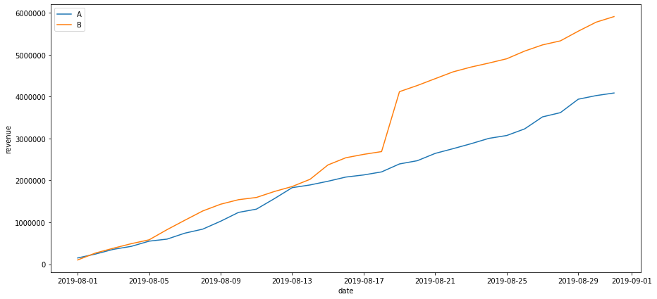

```python
# датафрейм с кумулятивным количеством заказов и кумулятивной выручкой по дням в группе А
cummulative_revenue_A = cummulative[cummulative['group']=='A'][['date','revenue', 'orders']]

# датафрейм с кумулятивным количеством заказов и кумулятивной выручкой по дням в группе B
cummulative_revenue_B = cummulative[cummulative['group']=='B'][['date','revenue', 'orders']]

# построим графики
fig, ax = plt.subplots(figsize=(15,7))
# Строим график выручки группы А
plt.plot(cummulative_revenue_A['date'], cummulative_revenue_A['revenue'], label='A')
ax.set_xlabel('date')
ax.set_ylabel('revenue')
# Строим график выручки группы B
plt.plot(cummulative_revenue_B['date'], cummulative_revenue_B['revenue'], label='B')

plt.legend()
```

Выручка почти равномерно увеличивается в течение всего теста - это хорошо, однако график *B* в точке по оси X(между 2019-08-17 и 2019-08-21) резко возрос. Это может сигнализировать о всплесках числа заказов, либо о появлении очень дорогих заказов в выборке.

#### 2) Постройте график кумулятивного среднего чека по группам. Сделайте выводы и предположения.

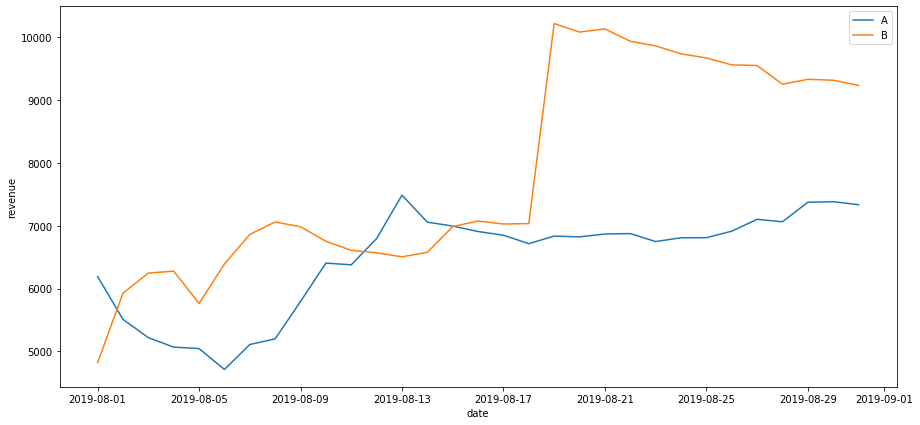

```python
fig, ax = plt.subplots(figsize=(15,7))
plt.plot(cummulative_revenue_A['date'], cummulative_revenue_A['revenue'] / cummulative_revenue_A['orders'], label='A')
plt.plot(cummulative_revenue_B['date'], cummulative_revenue_B['revenue'] / cummulative_revenue_B['orders'], label='B')
ax.set_xlabel('date')
ax.set_ylabel('revenue')
plt.legend()
```

Средний чек в группе *B* явно больше, видны резкие всплески, так же виден очень резкий всплеск между 17 и 21 днем. Возможно, в группе *B* попали крупные заказы. Тогда ей нужно больше данных, чтобы прийти к реальному среднему чеку и установиться на его уровне.

#### 3) Постройте график относительного изменения кумулятивного среднего чека группы B к группе A. Сделайте выводы и предположения.

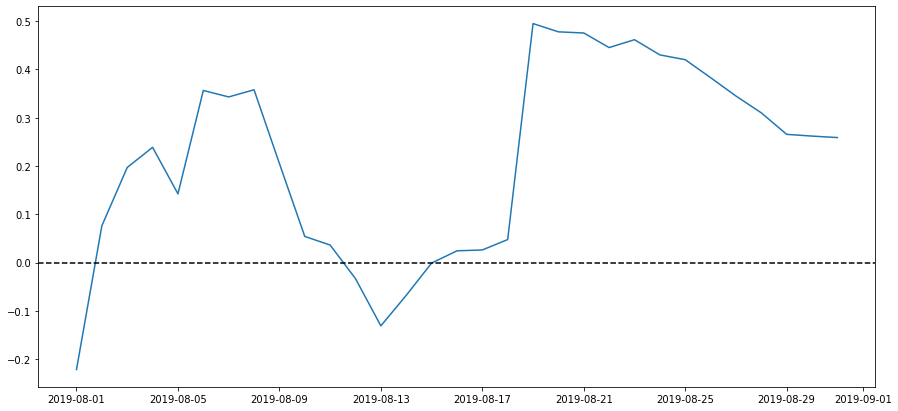

```python
# собираем данные в одном датафрейме
cummulative_revenue = cummulative_revenue_A.merge(cummulative_revenue_B, left_on='date', right_on='date', how='left', suffixes=['A', 'B'])

fig, ax = plt.subplots(figsize=(15,7))
# cтроим отношение средних чеков
plt.plot(cummulative_revenue['date'], (cummulative_revenue['revenueB'] / cummulative_revenue['ordersB'])/(cummulative_revenue['revenueA']/cummulative_revenue['ordersA'])-1)

# добавляем ось X
plt.axhline(y=0, color='black', linestyle='--')
```

В нескольких точках график резко скачет(есть выбросы и крупные значения)

#### 4) Постройте график кумулятивной конверсии по группам. Сделайте выводы и предположения.

```
['2019-08-01', '2019-09-01', 0, 0.045]
```

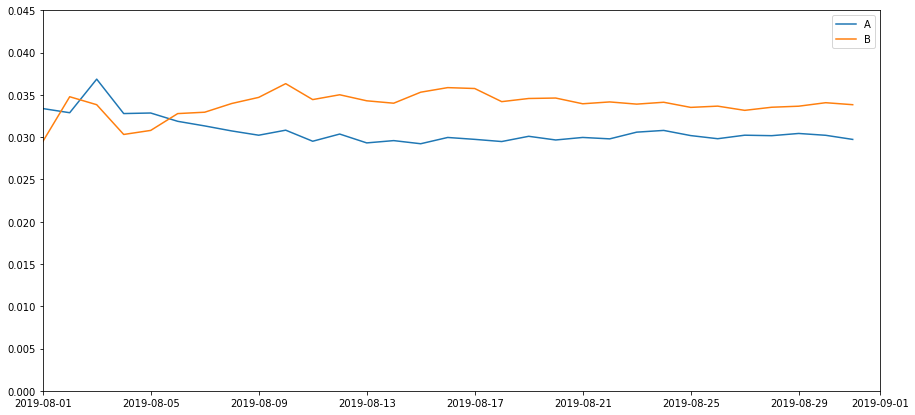

```python
# считаем кумулятивную конверсию
cummulative['conversion'] = cummulative['orders']/cummulative['visitors']

# отделяем данные по группе A
cummulative_A = cummulative[cummulative['group']=='A']

# отделяем данные по группе B
cummulative_B = cummulative[cummulative['group']=='B']
fig, ax = plt.subplots(figsize=(15,7))
# строим графики
plt.plot(cummulative_A['date'], cummulative_A['conversion'], label='A')
plt.plot(cummulative_B['date'], cummulative_B['conversion'], label='B')
plt.legend()

# задаем масштаб осей
plt.axis(["2019-08-01", '2019-09-01', 0, 0.045])
```

График получился почти симметричным, *B* вырвался вперед и в конце концов зафиксировался, конверсия *A* уменьшилась и так же зафиксировалась.

#### 5) Постройте график относительного изменения кумулятивной конверсии группы B к группе A. Сделайте выводы и предположения.

```
['2019-08-01', '2019-09-01', -0.3, 0.3]
```

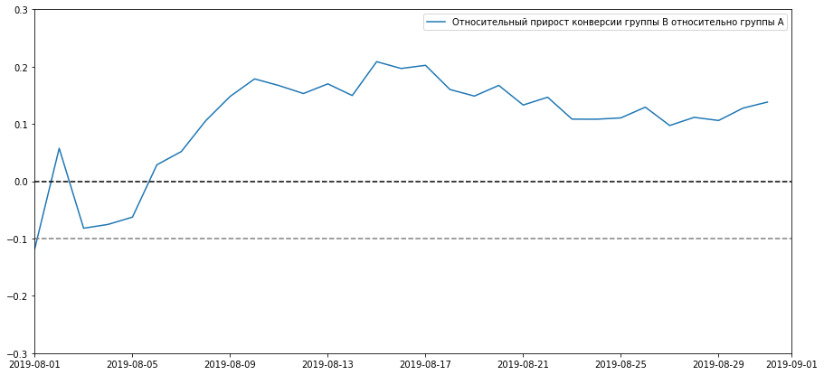

```python
cummulative_conversions = cummulative_A[['date','conversion']].merge(cummulative_B[['date','conversion']], left_on='date', right_on='date', how='left', suffixes=['A', 'B'])

fig, ax = plt.subplots(figsize=(15,7))
plt.plot(cummulative_conversions['date'], cummulative_conversions['conversionB']/cummulative_conversions['conversionA']-1, label="Относительный прирост конверсии группы B относительно группы A")
plt.legend()

plt.axhline(y=0, color='black', linestyle='--')
plt.axhline(y=-0.1, color='grey', linestyle='--')
plt.axis(["2019-08-01", '2019-09-01', -0.3, 0.3])
```

В начале теста группа B вырвалась вперёд, затем значительно проигрывала группе A. Потом её конверсия постепенно росла.

#### 6) Постройте точечный график количества заказов по пользователям. Сделайте выводы и предположения.

```python
data = orders.drop(['group', 'revenue', 'date'], axis=1)
data = data.groupby('visitor_id', as_index=False).agg({'transaction_id' : pd.Series.nunique})
data.columns = ['visitor_id','orders']
data.sort_values(by='orders',ascending=False).head(10)
```

|  | visitor_id | orders |
| --- | --- | --- |
| 1023 | 4256040402 | 11 |
| 591 | 2458001652 | 11 |
| 569 | 2378935119 | 9 |
| 487 | 2038680547 | 8 |
| 44 | 199603092 | 5 |
| 744 | 3062433592 | 5 |
| 55 | 237748145 | 5 |
| 917 | 3803269165 | 5 |
| 299 | 1230306981 | 5 |
| 897 | 3717692402 | 5 |

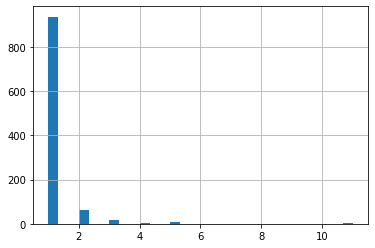

```python
data['orders'].hist(bins=30)
```

Большинство покупателей заказывали только один раз. Однако доля пользователей с 2-3 заказами незначительна.

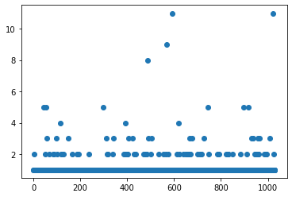

```python
x_values = pd.Series(range(0,len(data)))

plt.scatter(x_values, data['orders'])
```

Выводы подтверждаются: много пользователей с 1-3 заказами. Их точная доля не ясна — непонятно, считать их аномалиями или нет.

#### 7) Посчитайте 95-й и 99-й перцентили количества заказов на пользователя. Выберите границу для определения аномальных пользователей.

```python
np.percentile(data['orders'], [90, 95, 99])
```

```
array([1., 2., 4.])
```

Не более 5% пользователей оформляли больше чем 2 заказов. И 10% пользователей заказывали более одного раз. Разумно выбрать 3 или 4 заказов на одного пользователя за нижнюю границу числа заказов, и отсеять аномальных пользователей по ней.

#### 8) Постройте точечный график стоимостей заказов. Сделайте выводы и предположения.

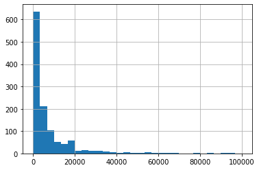

```python
orders['revenue'].hist(bins=30, range=(0,100000))
```

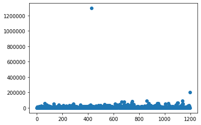

```python
x_values = pd.Series(range(0,len(orders)))

plt.scatter(x_values, orders['revenue'])
```

Так как есть большие выбросы, отсеем их по значению ~ 200.000, чтобы взглянуть на график более детально.

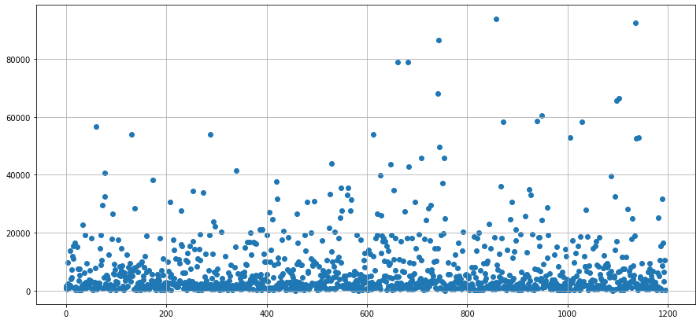

```python
fig, ax = plt.subplots(figsize=(15,7))
x_values = pd.Series(range(0,len(orders.query('revenue < 200000')['revenue'])))

plt.scatter(x_values, orders.query('revenue < 200000')['revenue'])
ax.grid()
```

Большинтсво пользователей лежит до 20.000

Посмотрим на перцентили

#### 9) Посчитайте 95-й и 99-й перцентили стоимости заказов. Выберите границу для определения аномальных заказов.

```python
qwerty = np.percentile(orders['revenue'], [90, 95, 99])
qwerty
```

```
array([18168. , 28000. , 58233.2])
```

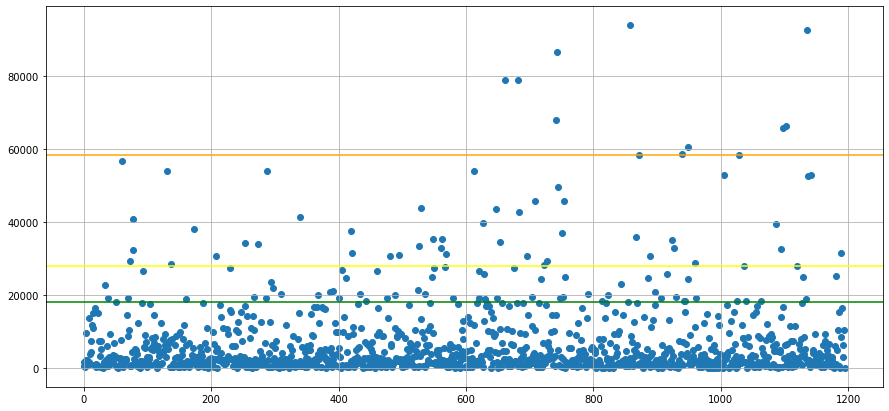

```python
fig, ax = plt.subplots(figsize=(15,7))
x_values = pd.Series(range(0,len(orders.query('revenue < 200000')['revenue'])))

plt.axhline(y = qwerty[0], color='green', linestyle='-')
plt.axhline(y = qwerty[1], color='yellow', linestyle='-')
plt.axhline(y = qwerty[2], color='orange', linestyle='-')
plt.scatter(x_values, orders.query('revenue < 200000')['revenue'])
ax.grid()
```

Да, действительно большинтсво лежит за чертой почти в 20.000. В дальнейшем отфильтруем данные по отметки в 28.000 и останетсяя у нас около 95% все остальное будем считать выбросами.

#### 10) Посчитайте статистическую значимость различий в конверсии между группами по «сырым» данным. Сделайте выводы и предположения.

```python
visitors_daily_A = visitors[visitors['group']=='A'][['date', 'visitors']] # количество пользователей в выбранную дату в группе A
visitors_daily_A.columns = ['date', 'visitors_per_date_A']

visitors_daily_B = visitors[visitors['group']=='B'][['date', 'visitors']] #количество пользователей в выбранную дату в группе B
visitors_daily_B.columns = ['date', 'visitors_per_date_B']

visitors_cummulative_A = visitors_daily_A.apply(lambda x: visitors_daily_A[visitors_daily_A['date'] <= x['date']].agg({'date' : 'max', 'visitors_per_date_A' : 'sum'}), axis=1)
visitors_cummulative_A.columns = ['date', 'visitors_cummulative_A'] # количество пользователей до выбранной даты включительно в группе A

visitors_cummulative_B = visitors_daily_B.apply(lambda x: visitors_daily_B[visitors_daily_B['date'] <= x['date']].agg({'date' : 'max', 'visitors_per_date_B' : 'sum'}), axis=1)
visitors_cummulative_B.columns = ['date', 'visitors_cummulative_B'] # количество пользователей до выбранной даты включительно в группе B

orders_daily_A = orders[orders['group']=='A'][['date', 'transaction_id', 'visitor_id', 'revenue']]\
    .groupby('date', as_index=False)\
    .agg({'transaction_id' : pd.Series.nunique, 'revenue' : 'sum'})
orders_daily_A.columns = ['date', 'orders_per_Date_A', 'revenue_per_Date_A']

orders_daily_B = orders[orders['group']=='B'][['date', 'transaction_id', 'visitor_id', 'revenue']]\
    .groupby('date', as_index=False)\
    .agg({'visitor_id' : pd.Series.nunique, 'revenue' : 'sum'})
orders_daily_B.columns = ['date', 'orders_per_Date_B', 'revenue_per_Date_B']


orders_cummulative_A = orders_daily_A.apply( #суммарная выручка до выбранной даты включительно в группе A
    lambda x: \
        orders_daily_A[orders_daily_A['date'] <= x['date']]\
            .agg({
                'date' : 'max',
                'orders_per_Date_A' : 'sum',
                'revenue_per_Date_A' : 'sum'}), axis=1).sort_values(by=['date'])
orders_cummulative_A.columns = ['date', 'orders_cummulative_A', 'revenue_cummulative_A']

orders_cummulative_B = orders_daily_B.apply(  # суммарная выручка до выбранной даты включительно в группе B
    lambda x: \
        orders_daily_B[orders_daily_B['date'] <= x['date']]\
            .agg({
                'date' : 'max',
                'orders_per_Date_B' : 'sum',
                'revenue_per_Date_B' : 'sum'}), axis=1).sort_values(by=['date'])
orders_cummulative_B.columns = ['date', 'orders_cummulative_B', 'revenue_cummulative_B']

data = orders_daily_A.merge(orders_daily_B, left_on='date', right_on='date', how='left')\
    .merge(orders_cummulative_A, left_on='date', right_on='date', how='left')\
    .merge(orders_cummulative_B, left_on='date', right_on='date', how='left')\
    .merge(visitors_daily_A, left_on='date', right_on='date', how='left')\
    .merge(visitors_daily_B, left_on='date', right_on='date', how='left')\
    .merge(visitors_cummulative_A, left_on='date', right_on='date', how='left')\
    .merge(visitors_cummulative_B, left_on='date', right_on='date', how='left')

ordersByUsersA = orders[orders['group']=='A'].groupby('visitor_id', as_index=False).agg({'transaction_id' : pd.Series.nunique})
ordersByUsersA.columns = ['visitor_id', 'orders']

ordersByUsersB = orders[orders['group']=='B'].groupby('visitor_id', as_index=False).agg({'transaction_id' : pd.Series.nunique})
ordersByUsersB.columns = ['visitor_id', 'orders']
```

```python
ordersByUsersA.head()
```

|  | visitor_id | orders |
| --- | --- | --- |
| 0 | 8300375 | 1 |
| 1 | 11685486 | 1 |
| 2 | 54447517 | 1 |
| 3 | 66685450 | 1 |
| 4 | 78758296 | 1 |

```python
ordersByUsersB.head()
```

|  | visitor_id | orders |
| --- | --- | --- |
| 0 | 5114589 | 1 |
| 1 | 6958315 | 1 |
| 2 | 8300375 | 1 |
| 3 | 39475350 | 1 |
| 4 | 47206413 | 1 |

```python
data.head()
```

|  | date | orders_per_Date_A | revenue_per_Date_A | orders_per_Date_B | revenue_per_Date_B | orders_cummulative_A | revenue_cummulative_A | orders_cummulative_B | revenue_cummulative_B | visitors_per_date_A | visitors_per_date_B | visitors_cummulative_A | visitors_cummulative_B |
| --- | --- | --- | --- | --- | --- | --- | --- | --- | --- | --- | --- | --- | --- |
| 0 | 2019-08-01 | 24 | 148579 | 20 | 101217 | 24 | 148579 | 20 | 101217 | 719 | 713 | 719 | 713 |
| 1 | 2019-08-02 | 20 | 93822 | 23 | 165531 | 44 | 242401 | 43 | 266748 | 619 | 581 | 1338 | 1294 |
| 2 | 2019-08-03 | 24 | 112473 | 16 | 114248 | 68 | 354874 | 59 | 380996 | 507 | 509 | 1845 | 1803 |
| 3 | 2019-08-04 | 16 | 70825 | 16 | 108571 | 84 | 425699 | 75 | 489567 | 717 | 770 | 2562 | 2573 |
| 4 | 2019-08-05 | 25 | 124218 | 23 | 92428 | 109 | 549917 | 98 | 581995 | 756 | 707 | 3318 | 3280 |

```python
# Количество пользователей, сумма всех элементов — количество заказов
sample_A = pd.concat([ordersByUsersA['orders'],pd.Series(0, index=np.arange(data['visitors_per_date_A'].sum() - len(ordersByUsersA['orders'])), name='orders')],axis=0)

sample_B = pd.concat([ordersByUsersB['orders'],pd.Series(0, index=np.arange(data['visitors_per_date_B'].sum() - len(ordersByUsersB['orders'])), name='orders')],axis=0)
```

```python
print("p-value: {0:.3f}".format(stats.mannwhitneyu(sample_A, sample_B)[1]))

print("Относительный прирост конверсии группы B: {0:.3f}".format(sample_B.mean()/sample_A.mean()-1))
```

```
p-value: 0.008
Относительный прирост конверсии группы B: 0.138
```

Вывод: По «сырым» данным различий в конверсии групп A и B есть. Первое число — p-value = 0.008 меньше 0.05. Значит, нулевую гипотезу о том, что статистически значимых различий в конверсии между группами нет, отвергаем. Однако относительный выигрыш группы B равен 13.8%.

#### 11) Посчитайте статистическую значимость различий в среднем чеке заказа между группами по «сырым» данным. Сделайте выводы и предположения.

```python
print("p-value: {0:.3f}".format(stats.mannwhitneyu(orders[orders['group']=='A']['revenue'], orders[orders['group']=='B']['revenue'])[1]))
print("Относительные различия в среднем чеке: {0:.3f}".format(orders[orders['group']=='B']['revenue'].mean()/orders[orders['group']=='A']['revenue'].mean()-1))
```

```
p-value: 0.365
Относительные различия в среднем чеке: 0.259
```

P-value значительно больше 0.05. Значит, причин отвергать нулевую гипотезу и считать, что в среднем чеке есть различия, нет. Впрочем, средний чек группы B значительно выше среднего чека группы A.

#### 12) Посчитайте статистическую значимость различий в конверсии между группами по «очищенным» данным. Сделайте выводы и предположения.

```python
users_many_orders = pd.concat([ordersByUsersA[ordersByUsersA['orders'] > 2]['visitor_id'], ordersByUsersB[ordersByUsersB['orders'] > 4]['visitor_id']], axis = 0)
users_expensive_orders = orders[orders['revenue'] > 28000]['visitor_id']
abnormalUsers = pd.concat([users_many_orders, users_expensive_orders], axis = 0).drop_duplicates().sort_values()
print(abnormalUsers.head(5))
print("Всего аномальных заказов: ", len(abnormalUsers))
```

```
1099    148427295
18      199603092
928     204675465
23      237748145
684     358944393
Name: visitor_id, dtype: int64
Всего аномальных заказов:  68
```

68 аномальных заказов, теперь узнаем как они повлияли на результаты

```python
sample_filtered_A = pd.concat([ordersByUsersA[np.logical_not(ordersByUsersA['visitor_id'].isin(abnormalUsers))]['orders'],pd.Series(0, index=np.arange(data['visitors_per_date_A'].sum() - len(ordersByUsersA['orders'])),name='orders')],axis=0)

sample_filtered_B = pd.concat([ordersByUsersB[np.logical_not(ordersByUsersB['visitor_id'].isin(abnormalUsers))]['orders'],pd.Series(0, index=np.arange(data['visitors_per_date_B'].sum() - len(ordersByUsersB['orders'])),name='orders')],axis=0)
```

Применим статистический критерий Манна-Уитни к полученным выборкам:

```python
print("{0:.3f}".format(stats.mannwhitneyu(sample_filtered_A, sample_filtered_B)[1]))
print("{0:.3f}".format(sample_filtered_B.mean()/sample_filtered_A.mean()-1))
```

```
0.006
0.204
```

#### 13) Посчитайте статистическую значимость различий в среднем чеке заказа между группами по «очищенным» данным. Сделайте выводы и предположения.

```python
print("{0:.3f}".format(stats.mannwhitneyu(
    orders[np.logical_and(
        orders['group']=='A',
        np.logical_not(orders['visitor_id'].isin(abnormalUsers)))]['revenue'],
    orders[np.logical_and(
        orders['group']=='B',
        np.logical_not(orders['visitor_id'].isin(abnormalUsers)))]['revenue'])[1]))

print("{0:.3f}".format(
    orders[np.logical_and(orders['group']=='B',np.logical_not(orders['visitor_id'].isin(abnormalUsers)))]['revenue'].mean()/
    orders[np.logical_and(
        orders['group']=='A',
        np.logical_not(orders['visitor_id'].isin(abnormalUsers)))]['revenue'].mean() - 1))
```

```
0.394
-0.017
```